# Intermediate R for social science

## Interlude: changing geom characteristics

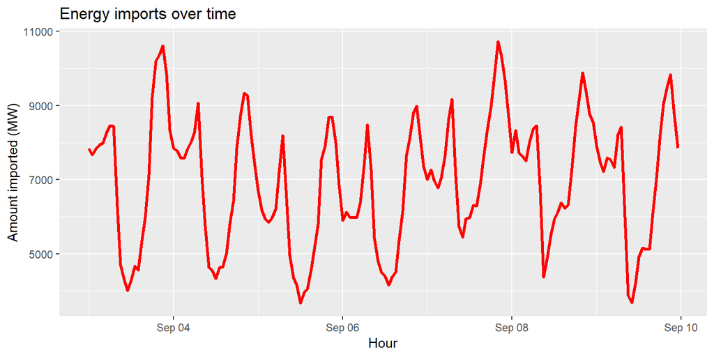

```r
ca_energy %>%
  ggplot() +
  geom_line(aes(x=datetime, y=imports), size=1.2, col="red") +
  labs(title="Energy imports over time", x="Hour", y="Amount imported (MW)")
```

## Area plots: `geom_area()`

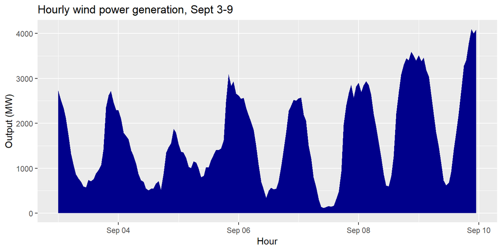

```r
ca_energy %>%
  ggplot() +
  geom_area(aes(x=datetime, y=wind), fill="darkblue") +
  labs(title="Hourly wind power generation, Sept 3-9", x="Hour", y="Output (MW)")
```

## Box plots: `geom_boxplot()`

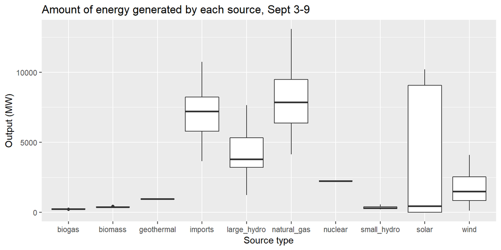

```r
ca_energy_long %>%
  ggplot() +
  geom_boxplot(aes(x=variable, y=value)) +
  labs(title="Amount of energy generated by each source, Sept 3-9", x="Source type", y="Output (MW)")
```

## Multiple geoms in one plot

Task:  
Plot a *scatterplot* of large hydro generation over time, and a *smoothed line* of the same relationship on top of it.

## Multiple geoms in one plot

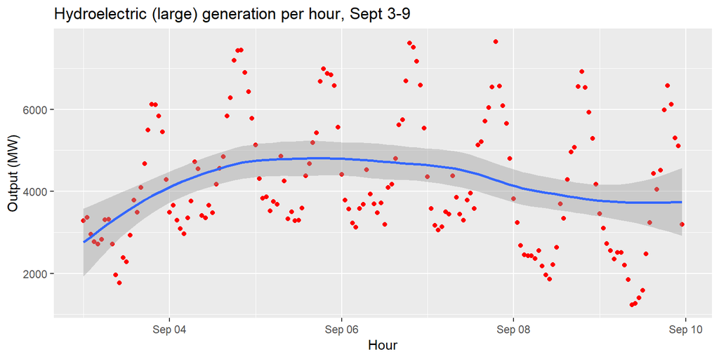

```r
ca_energy %>%
  ggplot() +
  geom_point(aes(x=datetime, y=large_hydro), col="red") +
  geom_smooth(aes(x=datetime, y=large_hydro)) +
  labs(title="Hydroelectric (large) generation per hour, Sept 3-9", x="Hour", y="Output (MW)")
```

## Exercise 3: Total output per source

Task:  
Create a column chart that shows the total output per source.

- Change the color of the columns to `"darkred"`.
- Add a meaningful title and axis labels using `labs()`.
- Bonus: Add a horizontal line using `geom_hline()` indicating the mean output across all sources.

## Exercise 3: Total output per source

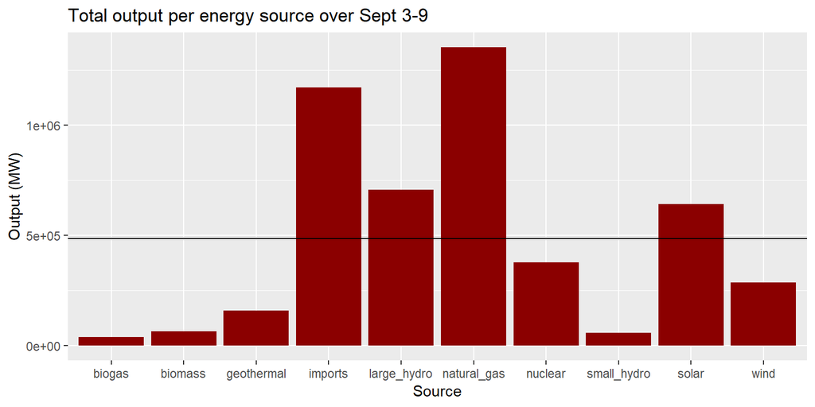

```r
ca_energy_long %>%
  group_by(variable) %>%
  summarise(total=sum(value)) %>%
  ggplot() +
  geom_col(aes(x=variable, y=total), fill="darkred") +
  geom_hline(aes(yintercept=mean(total))) +
  labs(title="Total output per energy source over Sept 3-9", y="Output (MW)", x="Source")
```

## Visualizing grouped data

- We often want to visualize multiple variables, or a variable that can be divided into groups, in one graphic.
- There are two broad principles for visualizing grouped variables in R:
  - Identify a grouping variable in a `geom(aes())` using the `group =` argument, and demarcate the distinct objects created per group in some way.
  - Use facets to generate geometric objects in separate coordinate systems for each group.

## Grouped data with colors/fill

Task:  
Create a line plot of energy output over time, with separate lines for each source.

Steps:

1. Supply the data frame `ca_energy_long` to `ggplot()`.
2. Add a `geom_line()` layer and specify `x=datetime` and `y=output`.
3. Also specify that `group=source` and `col=source`.
4. Add a `labs()` layer.

## Grouped data with colors/fill

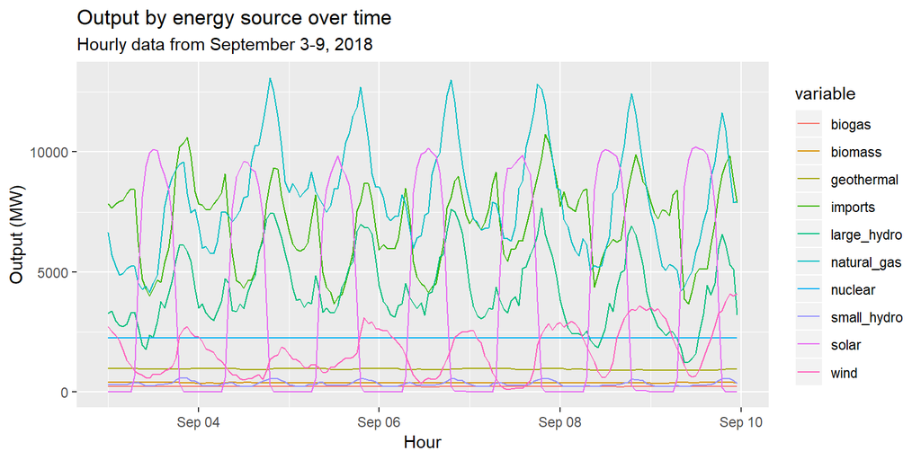

```r
ca_energy_long %>%
  ggplot() +
  geom_line(aes(x=datetime, y=value, group=variable, col=variable)) +
  labs(title="Output by energy source over time", subtitle="Hourly data from September 3-9, 2018", x="Hour", y="Output (MW)")
```

## Exercise 4: Grouped data with colors/fill

Task:  
Create a line plot that compares generation of wind and solar energy over time.

## Exercise 4: Colors and fill

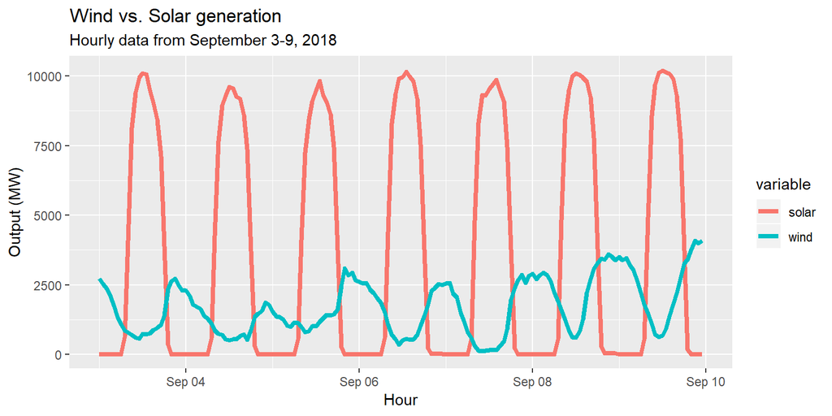

```r
ca_energy_long %>%
  filter(variable=="wind"|variable=="solar") %>%
  ggplot() +
  geom_line(aes(x=datetime, y=value, group=variable, col=variable), size=1.5) +
  labs(title="Wind vs. Solar generation", subtitle="Hourly data from September 3-9, 2018", x="Hour", y="Output (MW)")
```

## A note on colors and fill

- `col=` is used to color objects like lines and points
- `fill=` is used to color objects like columns and histograms
- After some trial and error, this will become intuitive

## Grouped data with position adjustment

Colors and fill are the most common method to demarcate grouped data. Position adjustment is the next most common.

## Example: Energy use by day

Task:  
Create a column chart of energy use by day, grouped by source.

Steps:

1. Modify `ca_energy_long` to summarize output by date and source.
   1. Use `mutate()` to create a `date` variable from `datetime`.
   2. Use `group_by()` and `summarize()` to calculate total output per date per source.
2. Supply modified data frame to `ggplot()`
3. Add a `geom_col()` layer, supply `x` and `y` aesthetics.
4. Specify `group=source` and `fill=source`.
5. Add a `labs()` layer.

## Example: Energy use by day

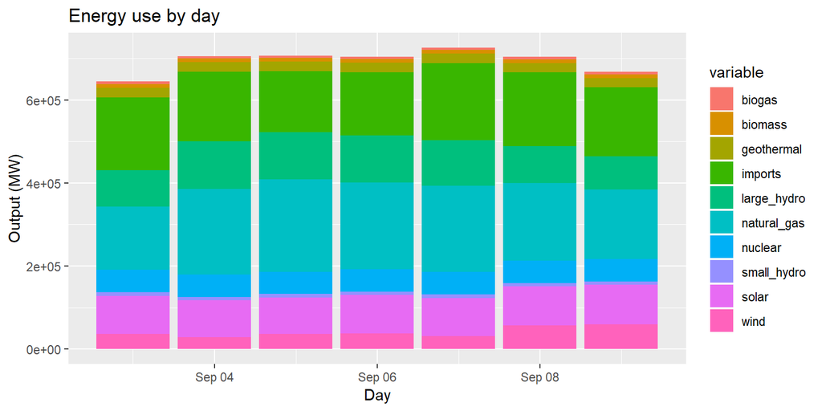

```r
ca_energy_long %>%
  mutate(date=date(datetime)) %>%
  group_by(date, variable) %>%
  summarize(value=sum(value)) %>%
  ggplot() +
  geom_col(aes(x=date, y=value, group=variable, fill=variable)) +
  labs(title="Energy use by day", x="Day", y="Output (MW)")
```

## Example: Energy use by day

- This column chart is useful if our main goal is to examine total output over time across sources.
- But what if our main goal is to compare trends across sources?
  - We can use `position="dodge"` in `geom_col()` ‘unstack’ the columns for each source.
- What if our goal is to compare what portion of output per day each source comprises?
  - We can use `position="fill"` to normalize height of stacked columns.

## Example: Energy use by day (pos dodge)

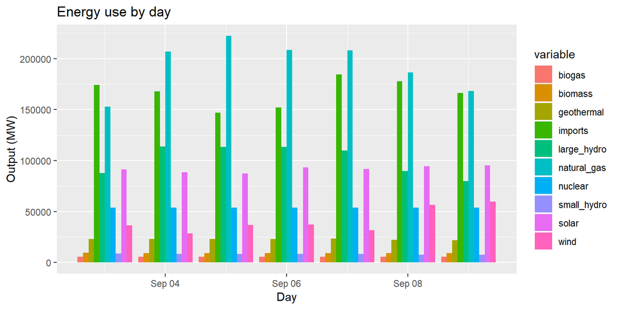

```r
ca_energy_long %>%
  mutate(date=date(datetime)) %>%
  group_by(date, variable) %>%
  summarize(value=sum(value)) %>%
  ggplot() +
  geom_col(aes(x=date, y=value, group=variable, fill=variable), position="dodge") +
  labs(title="Energy use by day", x="Day", y="Output (MW)")
```

## Example: Energy use by day (pos fill)

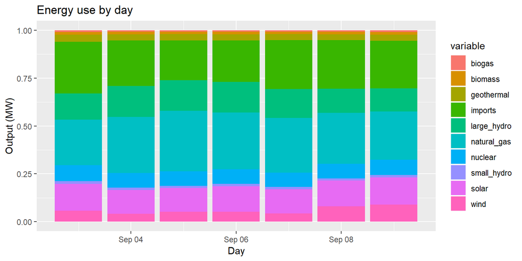

```r
ca_energy_long %>%
  mutate(date=date(datetime)) %>%
  group_by(date, variable) %>%
  summarize(value=sum(value)) %>%
  ggplot() +
  geom_col(aes(x=date, y=value, group=variable, fill=variable), position="fill") +
  labs(title="Energy use by day", x="Day", y="Output (MW)")
```